# Stats 405 Final Project Analysis

This project shows assessment data for Dashboard Alternative Status Schools (DASS) that participated in the DASS Growth Data Pilot, a project facilitated by the Charter Schools Development Center.

The main question that I was interested in was whether or not these charter schools were effective in teaching students. I wanted to measure this by looking at the distributions for each school and seeing how much of the students exhibited an increase in score from their initial test.

The first step towards my analysis was to find the increase (or decrease) in score between each test. The sum of the differences were found to determine how much each student changed from their first and last test. I also found the maximum increase for each student among all of the test recorded. I then labeled each student based on whether the student improved at all between any of the tests(maximum) and all of the tests(sum).

I was interested in the average initial score, maximum difference, and difference between the first and last test. I used an aggregate table to show this information below. I also wanted to show the number of data points from each school. It seems like only half of the students show an increase from the first and last test (sum), but will usually increase in roughly 1 grade level equivalency from their initial to highest test.

```
##    Group.1    test0       max          sum
## 1        1 6.095283 1.3699292  0.589740566
## 2        2 8.002817 0.9070423  0.398122066
## 3        3 8.027237 1.0964981  0.508171206
## 4        4 5.660304 1.4649240  0.863708207
## 5        5 7.140351 0.4280702 -0.142105263
## 6        6 8.660255 0.9616159 -0.001094999
## 7        7 8.194198 0.9957299 -0.113204920
## 8        8 9.503478 0.8795652  0.075652174
## 9        9 8.747023 0.9299237 -0.060000000
## 10      10 7.636111 0.6805556 -0.513888889
## 11      11 8.473293 1.0529697  0.027595960
## 12      12 7.153444 0.8528926 -0.202754821
## 13      13 8.291837 1.0367347  0.134693878
## 14      14 8.024736 0.7331924 -0.205073996
## 15      15 6.895640 0.8340599  0.263760218
## 16      16 8.000506 0.8984810 -0.062025316
```

```
##    Group.1    x
## 1        1  848
## 2        2  213
## 3        3  257
## 4        4 1645
## 5        5   57
## 6        6 3379
## 7        7 4309
## 8        8  230
## 9        9  655
## 10      10   36
## 11      11 2475
## 12      12  363
## 13      13  539
## 14      14  473
## 15      15  367
## 16      16  395
```

Since I only included students that had at least two tests, I wanted to see the difference in frequencies between them. There is a slight increase in mean when the student is given a second test. This offers some evidence that charter schools are having a positive effect.

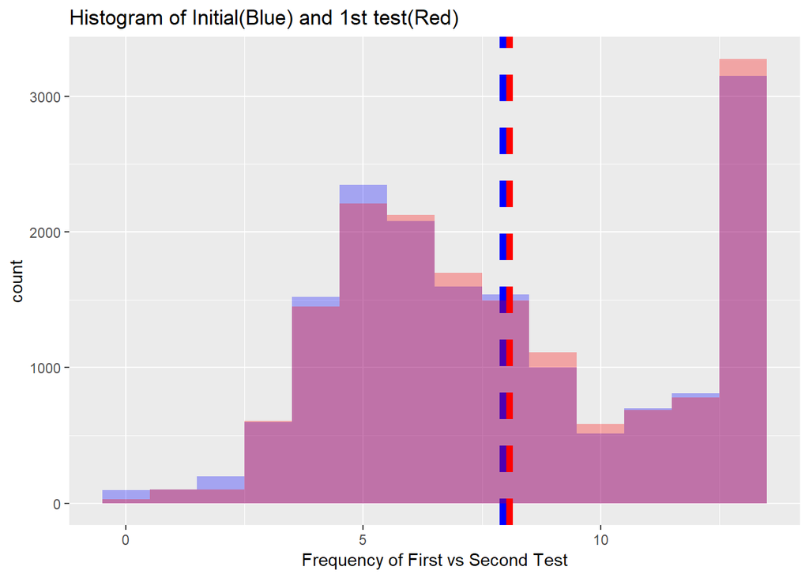

I decided to take a glimpse at some of the subgroup data. Only three schools ended up properly submitting subgroup data so I decided not to delve too deep into it. It’s clear to see that the English Learners and Special Ed (EL and IEP) both have lower initial test scores but do as well or even better than non EL and IEP students. There is some but not a noticeable difference between Free and Paid Lunch.

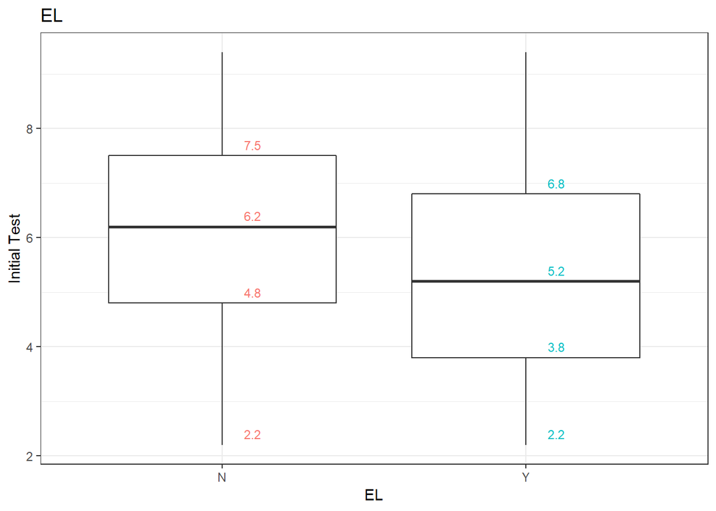

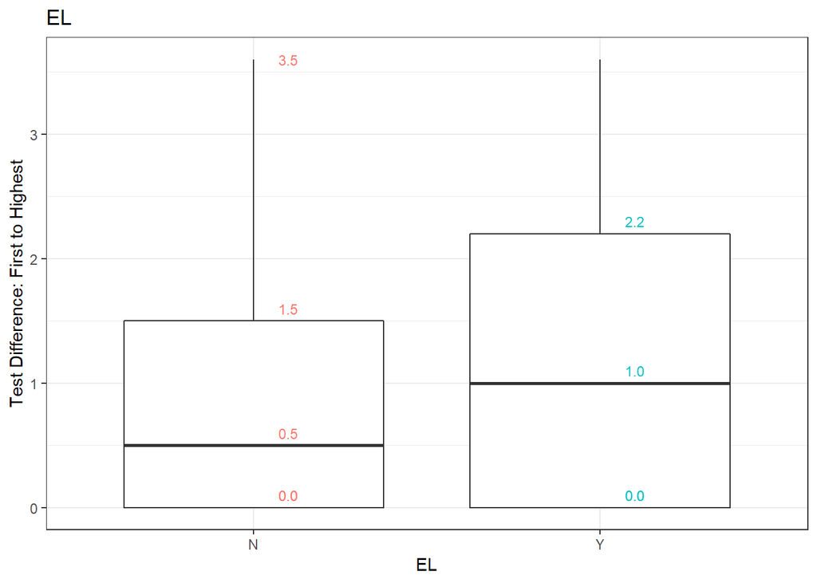

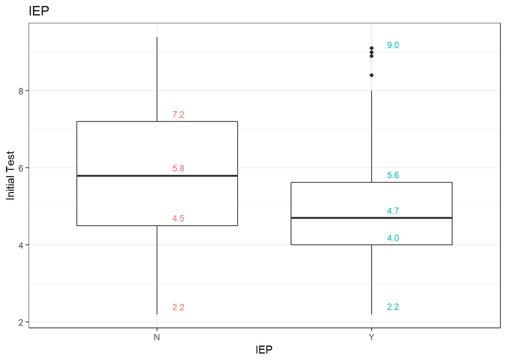

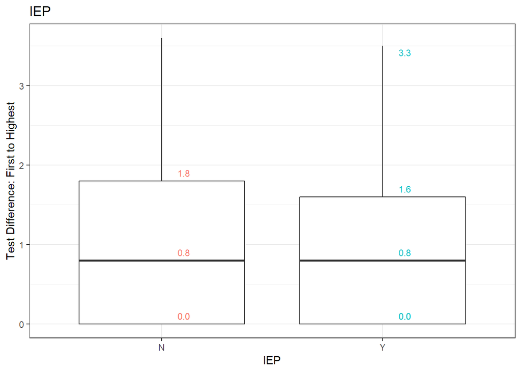

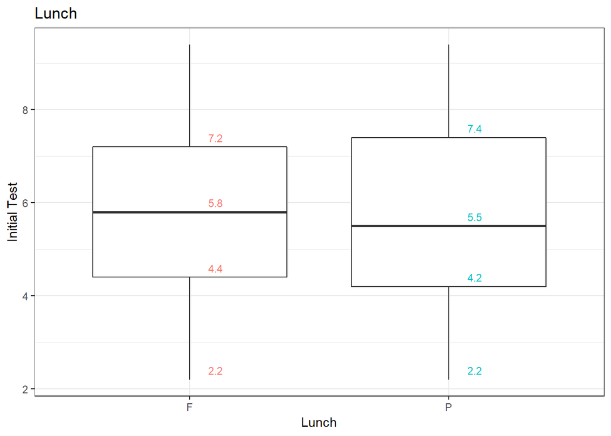

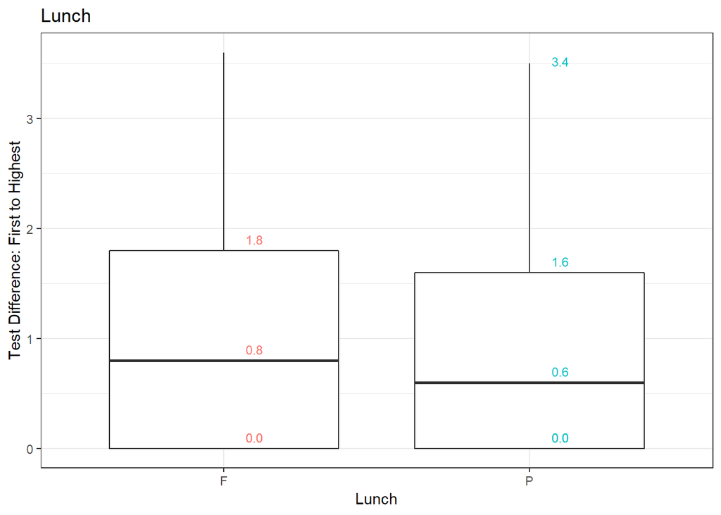

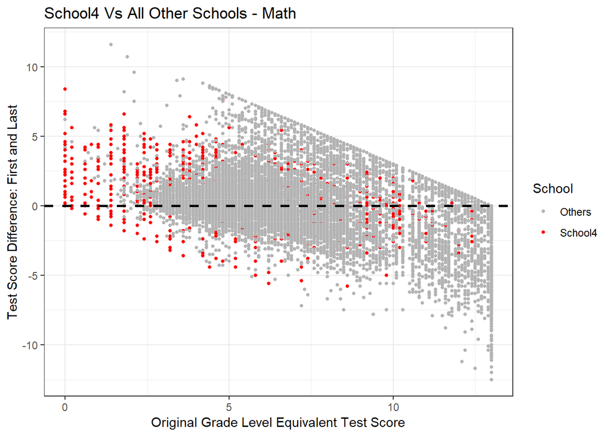

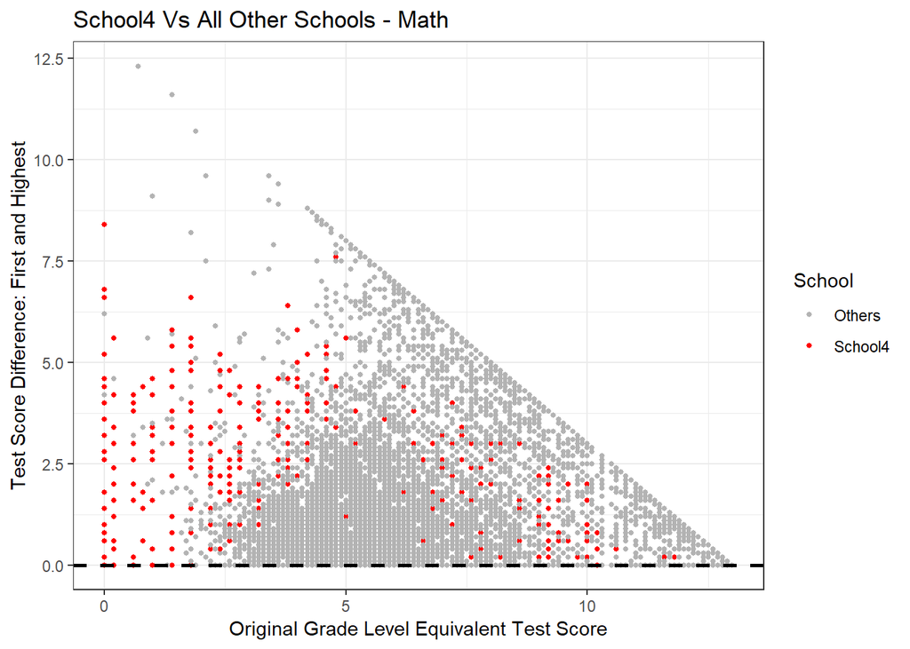

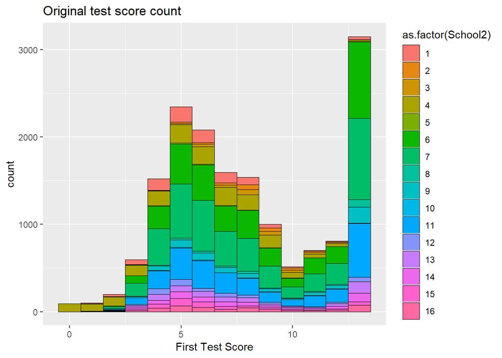

I could tell weird patterns in the data so I decided to remove some outliers:

Removed students having a “bad day” Students that scored 5 GE levels lower than the previous test Students that scored lower than .5 GE score after the first test

Removed students starting at grade equivalent test above 12th grade since these students were not likely to increase at all.

After removing these points, I decided to see the distribution of data side by side using boxplots. The blue line indicates the average for all schools and the red line indicates the average for the chosen school 4. We can see from the graph that though school 4 started well below the overall average, the students eventually exhibited an increase in math test scores when measured from the initial to highest post test scores when compared to all of the other schools. Though the increase is small, there is evidence that shows the charter school represented by group 4 has had a positive effect on the students.

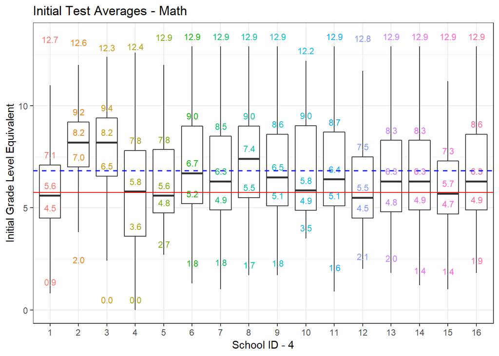

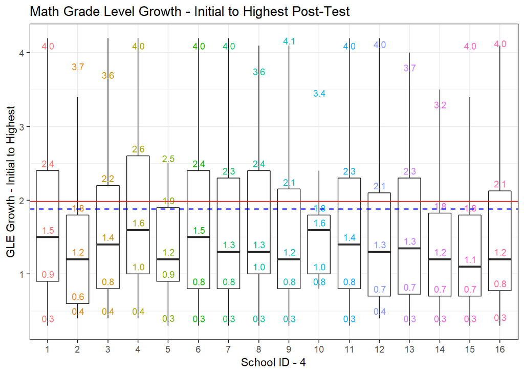